# TEMA 2 : Agrupamiento de OTUs

[figure not shown]

## 2.1 Unidades taxonómicas operativas (OTU):

Es una unidad de clasificación elegida por el investigador y utilizada para individualizar objetos biológicos de estudio, ya sea una especie u otro taxón de cualquier categoría, sin juzgar si corresponden a una entidad biológica particular.

Estas unidades taxonómicas son ampliamente usadas en métodos moleculares para el perfilado taxonómico del microbioma, genómica ambiental o análisis de dieta.

En métodos moleculares, su definición consiste en el agrupamiento de secuencias de acuerdo a un umbral de similitud de acuerdo al nivel taxonómico al que se busque aproximar. El valor de similitud más usado para secuencias del 16S rRNA es del 97% que busca acercarse al nivel de especie, o del 95% si busca acercarse al nivel de género.

## 2.2 Agrupamiento de OTUs en QIIME2

El plugin para agrupar OTUs en qiime2 es:

```bash
qiime vsearch
```

Los pasos del flujo de trabajo son:

1. Unir secuencias paired-end (omitir este paso si son secuencias single-end).
2. Filtrado de calidad
3. Dereplicación
4. Agrupamiento de secuencias

> 4.1 Método *de novo*

> 4.2 Método *closed-reference*

> 4.3 Método *open-reference*
5. Detección y remoción de quimeras

Agrupar secuencias o features en OTUs utilizando `vsearch` se puede hacer a partir de:

> Datos de secuencias demultiplexadas y filtradas por calidad (`SampleData[Sequences]`)

> Datos de tabla de features y secuencias representativas de características (que han sido dereplicadas y filtradas por calidad) (`FeatureTable[Frequency]` y `FeatureData[Sequence]`),

La dereplicación y filtrado de calidad actualmente se realiza en dos pasos, pero pronto estará disponible en un solo comando para mayor conveniencia.

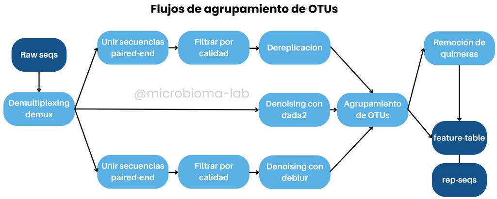

Vamos a crear el directorio del tema 2 y movernos a él:

```bash
cd
```

```bash
mkdir tema2
```

```bash
cd tema2
```

## 2.3 Descargar archivos de trabajo

Archivo de secuencias demultiplexadas:

```bash
wget 'https://docs.qiime2.org/2024.5/data/tutorials/atacama-soils/demux-subsample.qza' -O demux.qza
```